# Project3

Kelley Breeze and Chuanni He

2022-10-31

# Introduction

This report contains a set of predictive models with automating mechanism. The data to be analyzed is the Online News Popularity Data Set summarizing a heterogeneous set of features about articles published by Mashable in a period of two years. The goal is to predict the number of shares in social networks (popularity). The dataset contains 39,644 observations with 61 variables.  
In this project, we selected a subset of the variables as the predictor. Detailed descriptions for the predicting variables are listed below.

- `n_tokens_title`: Number of words in the title.
- `n_tokens_content`: Number of words in the content.
- `n_unique_tokens`: Rate of unique words in the content.
- `average_token_length`: Average length of the words in the content.
- `num_keywords`: Number of keywords in the metadata.
- `num_hrefs`: Number of links.
- `num_imgs`: Number of images.
- `num_videos`: Number of videos.
- `kw_min_min`: Worst keyword (min. shares).
- `kw_max_min`: Worst keyword (max. shares).
- `self_reference_min_shares`: Min. shares of referenced articles in Mashable.
- `self_reference_max_shares`: Max. shares of referenced articles in Mashable.
- `weekday_is_friday`: Was the article published on a Friday?
- `weekday_is_saturday`: Was the article published on a Saturday?
- `global_rate_positive_words`: Rate of positive words in the content.
- `global_rate_negative_words`: Rate of negative words in the content.

The target variables is the `shares` variable indicating number of shares (target). The purpose of this project is to identify the optimal predicting variables and methods to predict the number of shares. This project applied statistical prediction models such as linear regression, random forest model, and boosted tree model.

#### Packages Used

```r
library(tidyverse)
library(caret)
library(corrplot)
library(gbm)
library(randomForest)
```

# Data

The code below uses a relative file path to import our data.

```r
onlineNewsData<-read_csv('OnlineNewsPopularity.csv')
```

# Subset the data

We create a new variable `data_channel` representing all data channels, and remove the six data channel variables. Next, we clean up the dataset to only include predicting variables and the response variable.

```r
data_channel = rep(NA,nrow(onlineNewsData[,1]))
for (i in 1:nrow(onlineNewsData[,1])) {
  if (onlineNewsData$data_channel_is_lifestyle[i]==1) {data_channel[i]="lifestyle"}
  else if (onlineNewsData$data_channel_is_entertainment[i]==1) {data_channel[i]="entertainment"}
  else if (onlineNewsData$data_channel_is_bus[i]==1) {data_channel[i]="bus"}
  else if (onlineNewsData$data_channel_is_socmed[i]==1) {data_channel[i]="socmed"}
  else if (onlineNewsData$data_channel_is_tech[i]==1) {data_channel[i]="tech"}
  else if (onlineNewsData$data_channel_is_world[i]==1) {data_channel[i]="world"}
  else {data_channel[i]=NA}
}
onlineNewsData = onlineNewsData[,-c(14:19)]
onlineNewsData = cbind(onlineNewsData,data_channel)
onlineNewsData = onlineNewsData %>%
  select(data_channel,n_tokens_title,n_tokens_content,n_unique_tokens,
         average_token_length,num_keywords,num_hrefs,num_imgs,num_videos,
         kw_min_min,kw_max_min,self_reference_min_shares,self_reference_max_shares,
         weekday_is_friday,weekday_is_saturday,global_rate_positive_words,
         global_rate_negative_words,shares) %>% filter(data_channel=="lifestyle")
```

# Summarizations

First, let’s summarize the training data to look at the basic distribution of our selected variables. We need to fist split the data into training set and test set.

```r
set.seed(123)
train = sample(1:nrow(onlineNewsData), size = nrow(onlineNewsData)*0.7)
test = setdiff(1:nrow(onlineNewsData), train)

dat_train <- onlineNewsData[train, ]
dat_test <- onlineNewsData[test, ]
```

The response variable that we are interested in is the `shares` variable. Let’s look at some basic summary statistics for the `shares` variable.

```r
summary(dat_train$shares)
```

```
##    Min. 1st Qu.  Median    Mean 3rd Qu.    Max.
##      28    1100    1700    3870    3300  208300
```

Let’s also look at a histogram for the `shares` variable to get an idea of the spread of this variable.

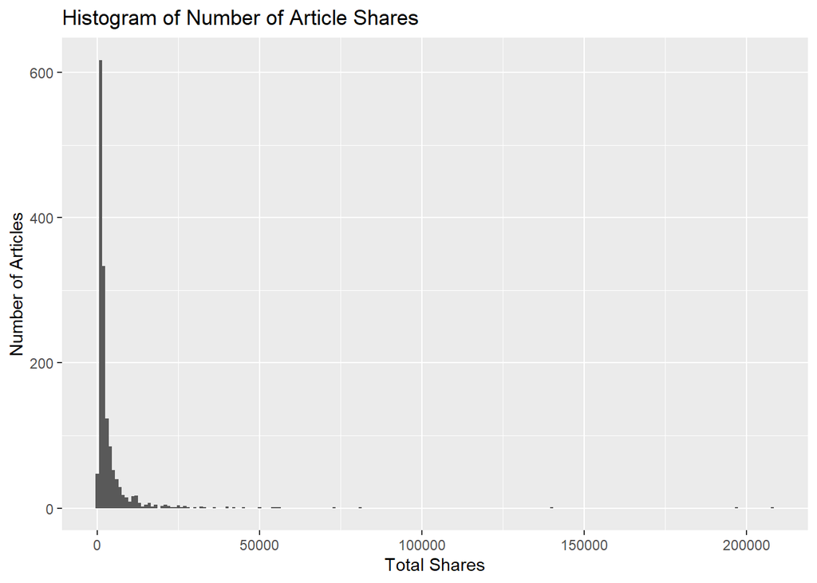

```r
ggplot(dat_train, aes(x=shares)) +
  geom_histogram(binwidth = 1000) +
  labs(x="Total Shares", y="Number of Articles", title = "Histogram of Number of Article Shares")
```

Next we will do some summarization statistics and plots. We first make a scatter plot showing the relationship between `share` and `num_image`. If the points show an upward trend, then articles with more images tend to be shared more often. If we see a negative trend then articles with more images tend to be shared less often.

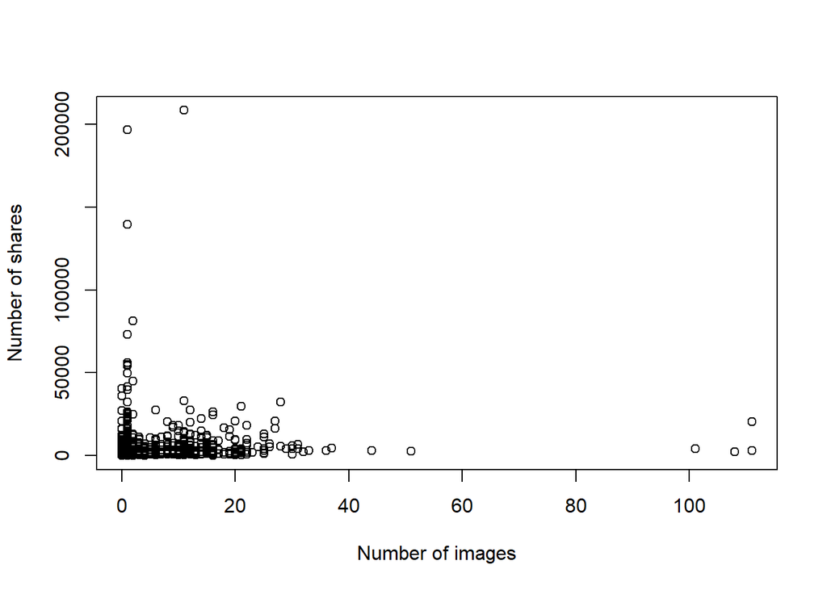

```r
plot(dat_train$num_imgs,dat_train$shares,type = "point",xlab = "Number of images",
     ylab = "Number of shares")
```

Next, we want to investigate the correlation between numeric variables. If the correlation coefficient is large and positive with `share`, then the higher the value of the corresponding variable, the more shares it tends to have. If the correlation coefficient is small and negative with `share`, then the higher the value of the corresponding variable, the less shares it tends to have.

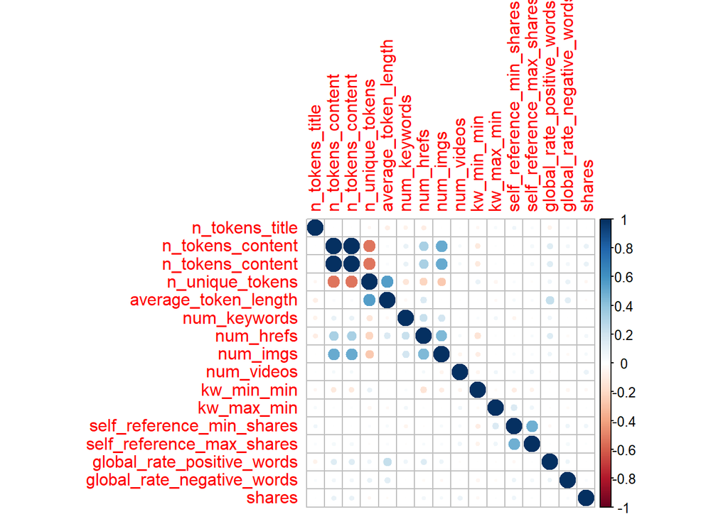

```r
cor_mat = cor(cbind(n_tokens_title=dat_train$n_tokens_title, n_tokens_content=dat_train$n_tokens_content,
                    n_tokens_content=dat_train$n_tokens_content,n_unique_tokens=dat_train$n_unique_tokens,
                    average_token_length=dat_train$average_token_length,num_keywords=dat_train$num_keywords,
                    num_hrefs=dat_train$num_hrefs,num_imgs=dat_train$num_imgs,num_videos=dat_train$num_videos,
                    kw_min_min=dat_train$kw_min_min,kw_max_min=dat_train$kw_max_min,
                    self_reference_min_shares=dat_train$self_reference_min_shares,
                    self_reference_max_shares=dat_train$self_reference_max_shares,
                    global_rate_positive_words=dat_train$global_rate_positive_words,
                    global_rate_negative_words=dat_train$global_rate_negative_words,shares=dat_train$shares))
corrplot(cor_mat)
```

Next, we also want to know whether the article is published during weekends will affect the shares. We use Friday and Saturday data as an illustration. If the box for Saturday subset is overall higher than that for Friday, we can say that the shares might be more for news published during weekends. If the box for Saturday subset is overall lower than that for Friday, we can say that the shares might be fewer for news published during weekends.

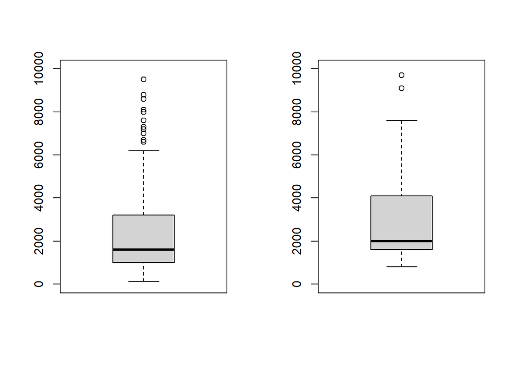

```r
par(mfrow=c(1,2))
boxplot(dat_train$shares[dat_train$weekday_is_friday==1], ylim=c(0,10000))
boxplot(dat_train$shares[dat_train$weekday_is_saturday==1], ylim=c(0,10000))
```

We made two contingency tables to list the number of publications on Fri. and Sat.

```r
table(dat_train$weekday_is_friday)
```

```
##
##    0    1
## 1252  217
```

```r
table(dat_train$weekday_is_saturday)
```

```
##
##    0    1
## 1347  122
```

The positive words and negative words ratio can provide an overall attitude of the corresponding news. We made five-point summary statistics to investigate the distributions.

```r
summary(dat_train$global_rate_positive_words)
```

```
##    Min. 1st Qu.  Median    Mean 3rd Qu.    Max.
## 0.00000 0.03465 0.04370 0.04443 0.05333 0.12139
```

```r
summary(dat_train$global_rate_negative_words)
```

```
##    Min. 1st Qu.  Median    Mean 3rd Qu.    Max.
## 0.00000 0.01046 0.01552 0.01641 0.02115 0.05785
```

Let’s also look at how positive words are related to shares and number of images in an article. The scatter plot below shows the number of positive words in an article, colored by the number of images contained in the article.

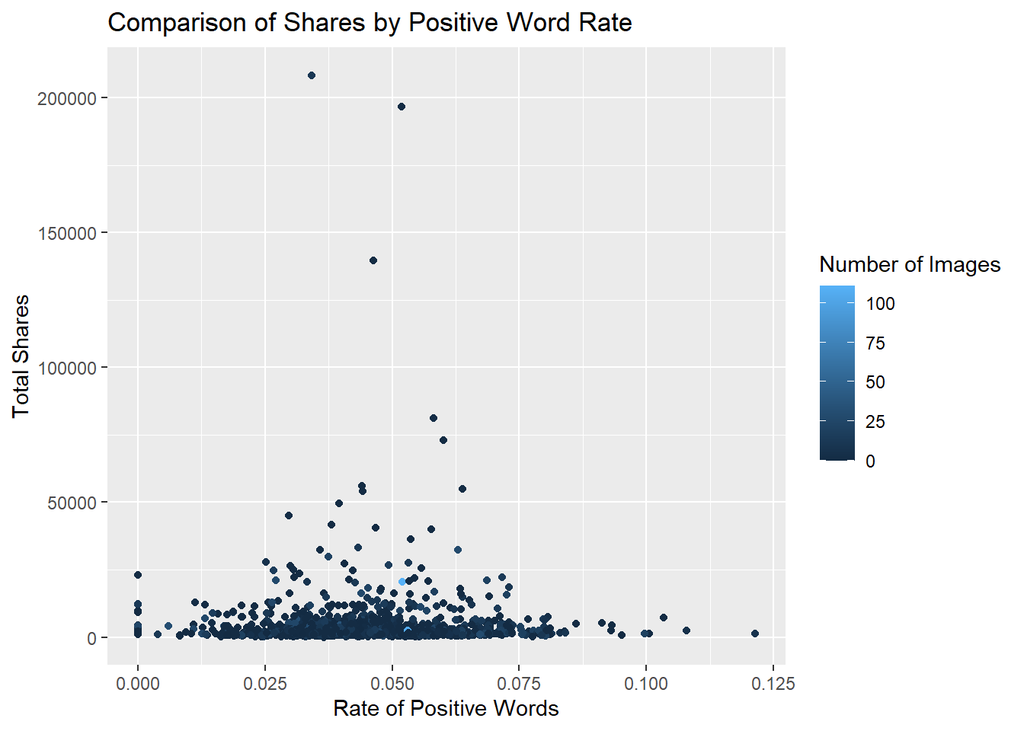

```r
ggplot(dat_train, aes(x=global_rate_positive_words, y=shares, color=num_imgs)) +
  geom_point() +
  labs(title="Comparison of Shares by Positive Word Rate",
       x="Rate of Positive Words",
       y="Total Shares") +
  scale_color_gradient(name="Number of Images")
```

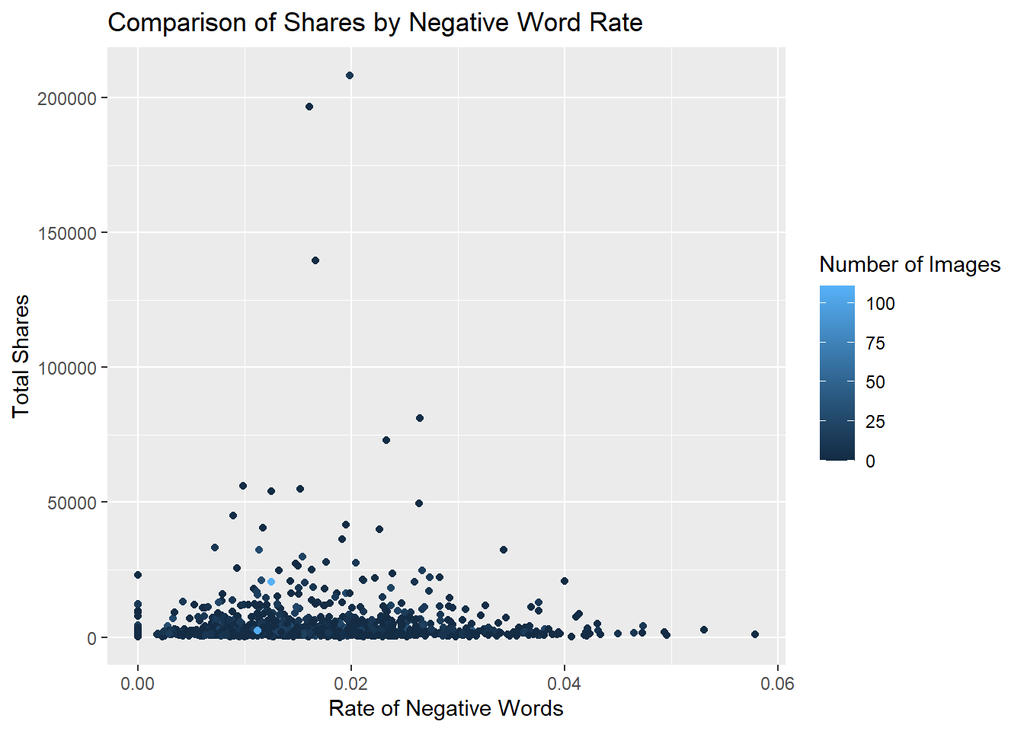

```r
ggplot(dat_train, aes(x=global_rate_negative_words, y=shares, color=num_imgs)) +
  geom_point() +
  labs(title="Comparison of Shares by Negative Word Rate",
       x="Rate of Negative Words",
       y="Total Shares") +
  scale_color_gradient(name="Number of Images")
```

# Modeling

#### Spliting the Data

The entire dataset has been split into training set and test set in the Summarizations section. The training set is `dat_train` and the test set is `dat_test`.

### Random Forest Model

Random forest models create multiple trees from bootstrap samples and average the results, which provides a reduction in variability of predictions when compared to a single tree model. Random forests use a random subset of the predictors for each bootstrap sample/tree fit. At each step along the way the random forest model is only using a random subset (*m*) of predictors to choose from when splitting the data, as opposed to the entire set of *p* predictors in the data set. One of the core strengths of the random forest model is it’s ability to decorrelate the trees that are produced, which helps to decrease the resulting variance in our final model.

The random forest model helps to avoid a problem that can arise if there is a single very strong predictor that exists in the data set. If there is a single strong predictor in the data set, every bootstrap tree is likely to use that predictor for its first split, resulting in bagged tree predictions that are more correlated to one another, and thereby giving a smaller reduction in the variance from aggregation. The same issue arises when there are a large number of highly correlated predictors in the data set as well, and this problem can be addressed by creating a random forest model with a small *m* value. As the goal of ensemble methods is to reduce variance in order to increase prediction success, when there is one strong predictor, or several correlated predictors, we will likely want to select a random forest model over a bagged tree model.

In training the random forest model we are using cross-validation with 5 folds. We are also using values of `1:5` for `mtry` to find the optimal model. Lowest RMSE value was used to identify the optimal model. We then trained a final model to obtain the test MSE based on the test set.

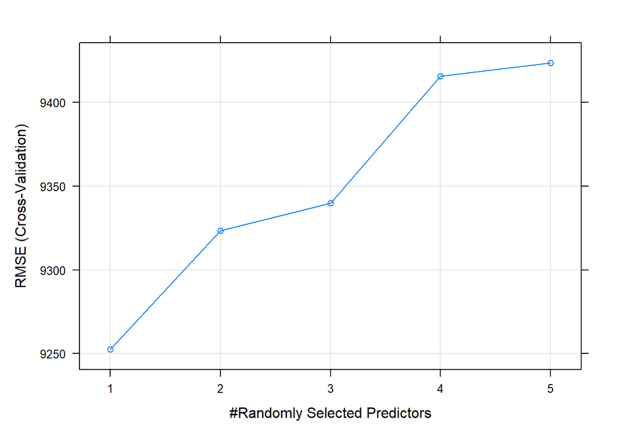

```r
random_forest<- train(shares ~., data = dat_train[,-1],
                     method = "rf",
                     preProcess = c("center", "scale"),
                     tuneGrid = data.frame(mtry=1:5),
                     trControl = trainControl(method = "cv",
                                              number = 5))

plot(random_forest)
```

```r
best = which.min(random_forest$results$RMSE)
random_forest$results[best,]
```

```
##   mtry     RMSE   Rsquared      MAE   RMSESD RsquaredSD    MAESD
## 1    1 9252.434 0.03375136 3588.523 4678.509 0.04510721 545.0069
```

```r
random_forest_final = randomForest(formula = shares ~ .,data = dat_train[,-1],distribution = "gaussian",
                     mtry=random_forest$results[best,]$mtry)

MSE_random_forest = mean((dat_test$shares-predict(random_forest_final, newdata = dat_test))^2)
```

### Boosted Tree Model

The basic principles of gradient boosting are as follows: given a loss function and a weak learner, the algorithm finds an additive model that minimizes the loss function. The algorithm is initialized with the best guess of the response. The gradient is calculated, and a model is then fit to the residuals to minimize the loss function. The current model is added to the previous model, and the procedure continues for a number of iterations that the user specified.

Based on such inferences, we have fit a gradient boosting model with the RSS loss (distribution = “gaussian”), the sequentially generated trees (n.trees), shrinkage, and interaction depth are the tuning parameter to make the tune grid. We set tree control parameter minimum number of observations in a node to be 10 (n.minobsinnode = 10). We also specified use of 5-fold CV to estimate test error rate. By default, the bagging fraction is taken to be 0.5 (bag.fraction = 0.5 is not specified as it is default). We identified the best fit in terms of minimal RMSE, and trained a final model to obtain the test MSE based on the test set.

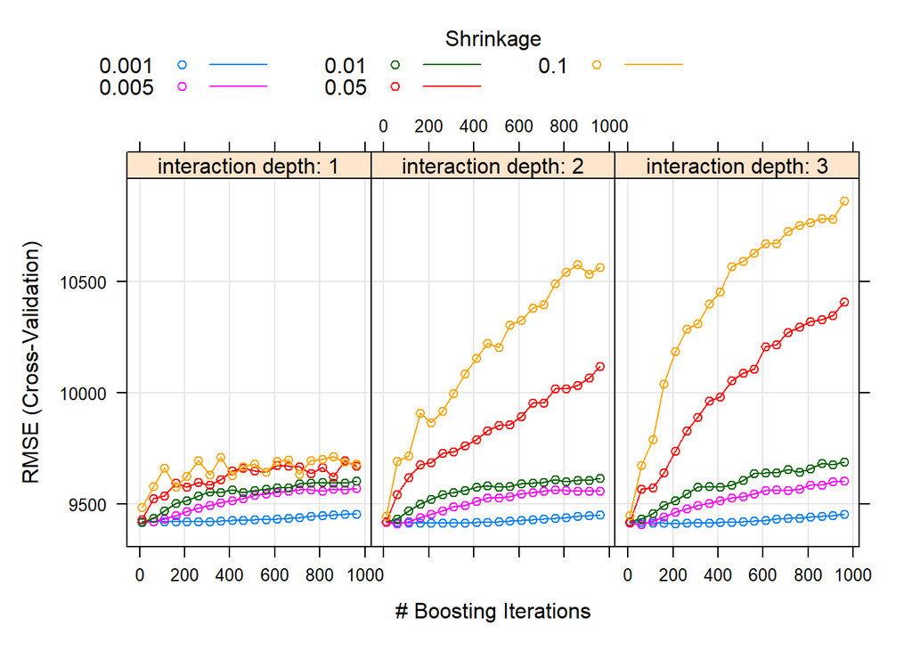

```r
set.seed(123)
gr = expand.grid(shrinkage = c(0.1, 0.05, 0.01, 0.005, 0.001),
                 interaction.depth = c(1,2,3),n.trees = seq(10, 1000, by=50),
                 n.minobsinnode = 10)
boosting = train(shares ~ .,data = dat_train[,-1],method = "gbm",
                  trControl = trainControl(method = "cv",number = 5),
                  tuneGrid = gr,verbose = FALSE)

plot(boosting)
```

```r
best = which.min(boosting$results$RMSE)
boosting$results[best,]
```

```
##     shrinkage interaction.depth n.minobsinnode n.trees     RMSE   Rsquared
## 102     0.005                 3             10      60 9407.907 0.01085015
##          MAE   RMSESD RsquaredSD    MAESD
## 102 3579.669 4219.165  0.0222335 524.3258
```

```r
boosting_final = gbm(formula = shares ~ .,data = dat_train[,-1],distribution = "gaussian",
                     n.trees = boosting$results[best,]$n.trees,
                     shrinkage = boosting$results[best,]$shrinkage,
                     interaction.depth = boosting$results[best,]$interaction.depth,
                     n.minobsinnode = 10)

MSE_boosting = mean((dat_test$shares-predict(boosting_final, newdata = dat_test))^2)
```

```
## Using 60 trees...
```

## Linear Regression Models

Linear regression provides a relatively simple way to predict a quantitative response. In a simple linear regression we use a single predictor $X$ to predict a response $Y$. In a simple linear model we have two unknown constants, $\beta_{0}$ represents the intercept and $\beta_{1}$ represents the slope. $\beta_{0}$ is the expected value of $Y$ when $X=0$. $\beta_{1}$ is the average change in $Y$ that is associated with an increase of one-unit of $X$. In linear regression we use our training data to produce estimated values for $\beta_{0}$ and $\beta_{1}$ which can then be used to make predictions on our test data.

We can extend our simple linear regression model to include more than one predictor variable by assigning a different slope to each predictor variable in our model. We can also add interaction terms to our linear model to show effects of our predictor variables on one another, and the associated impact they have on our response variable. For example, in this data perhaps the number of shares is impacted by the number of images in an article when the average word length of the article is low but not when the average word length is high. In this situation adding an interaction term could help to better predict the number of shares by accounting for the interaction between number of images and average words length in the article.

The most common way in which to fit a linear regression model is by minimizing the least squares. In the linear regression models here we want to minimize the test MSE to find the best model.

### First Linear Regression Model `lmod1`

For the first linear regression model, we fit a full model without interaction term. Then obtain the test MSE on the test set.

```r
lmod1 = lm(shares~., data = dat_train[,-1])
MSE_lmod1 = mean((dat_test$shares-predict(lmod1, newdata = dat_test))^2)
```

### Second Linear Regression Model `lmod2`

The second linear regression model will fit a model with main effect and interaction terms for `num_imgs`, `num_keywords`, `global_rate_negative_words`, and `average_token_length`.

```r
lmod2 = lm(shares~ num_imgs*num_keywords*global_rate_negative_words*average_token_length, data = dat_train[,-1])
MSE_lmod2 = mean((dat_test$shares-predict(lmod2, newdata = dat_test))^2)
```

# Comparison

We applied the MSE metric to represent the performance for different models. Next, the MSE metrics for all the four models (`lmod1`, `lmod2`, `random_forest`, and `boosting`) were compared. The best model with minimal test MSE values were identified as the winner.

```r
model_name<-c("Random Forest Model", "Boosted Model", "Linear Model 1", "Linear Model 2")
MSE_values<-c(MSE_random_forest, MSE_boosting, MSE_lmod1, MSE_lmod2)
MSE_comparison_df<-tibble(model_name, MSE_values)

index = which.min(MSE_comparison_df$MSE_values)
print(paste0("The winner model is:",model_name[index]))
```

```
## [1] "The winner model is:Random Forest Model"
```

# Automation